# Inference introduction using binomial data

# Intro

Today, we’ll go through what was in the lecture, building up from simple coin flips, through to p values and confidence intervals for a proportion test (in this case for election data).

I want to start with using `rbinom` to model coin flips - there’s a couple of reasons for doing this:

- It will (hopefully) help to understand where p-values come from
- Make clear what ‘probability density functions’ actually are and why they’re useful
- By learning this one branch of the distribution family of functions, it’ll help understand that they’re all doing basically the same thing. That is, once we’ve played with the **binomial distribution**, using all others like the **normal distribution** will make a lot more sense (again, hopefully!)

## Introduction to the binomial family of functions in R

R has a bunch of functions for using statistical distributions that help massively when simulating.

Let’s start with something simple: **using the `rbinom` function to simulate fair coin flips**.

A coin flip is an example of a **binomial trial** (also known as a **Bernoulli trial**): a binary chance event - with *success* or *failure* as outcomes (heads or tails in the coin example), and where the probability is the same on each trial.

This is equivalent to a single coin flip fifty times.

```r
rbinom(n = 50, size = 1, prob = 0.5)
```

```
##  [1] 1 0 0 0 0 0 0 1 1 0 0 0 1 0 0 0 1 1 0 0 0 0 1 1 0 1 1 0 1 0 1 1 0 1 0 1 0 0
## [39] 1 1 0 0 1 0 0 1 0 1 1 1
```

If we **store** our fifty coin flips in an object, each `n = 50` becomes an observation stored in a vector. We can then find summaries about the number of heads and tails, starting just with using `table`:

find out the **proportion of heads** using mean (this will be slightly different for everyone because of the different number of random “successes”):

```r
flips <- rbinom(n = 50, size = 1, prob = 0.5)
table(flips)
```

```
## flips
##  0  1
## 31 19
```

We can also use `mean` - finding the average of all the 1s and 0s gives us the proportion of 1s:

```r
mean(flips)
```

```
## [1] 0.38
```

> **Recap: using *mean* to find proportions and probabilities**:

A reminder about why this works: for any vector of ones and zeroes, finding the mean will find the proportion. We can illustrate just by making one from scratch:

```r
x <- c(0,0,0,1)
mean(x)
```

```
## [1] 0.25
```

And note, as mentioned in the lecture, **R will treat TRUEs and FALSEs as ones and zeroes** for certain functions and for logical operators. This will be very useful later. But just to prove the point (using T and F in place of the full TRUE and FALSE):

```r
y <- c(F,F,F,T)
mean(y)
```

```
## [1] 0.25
```

> **Back to coin flips again**:

We can see how the random coin flips vary by **highlighting the code before we run it**. That allows us to re-run it repeatedly. We can see how the total number of “successes” varies. Let’s do that with the code chunk where we set flips, then find a table and the mean. **Notice how the proportion jumps around the 0.5 value.**

```r
flips <- rbinom(n = 50, size = 1, prob = 0.5)
flips
```

```
##  [1] 0 0 0 1 1 0 1 0 1 1 0 0 1 1 0 0 1 0 1 0 0 1 1 0 0 0 0 0 1 1 1 0 1 1 0 0 0 1
## [39] 1 1 1 1 1 1 0 1 0 1 1 1
```

```r
table(flips)
```

```
## flips
##  0  1
## 23 27
```

```r
mean(flips)
```

```
## [1] 0.54
```

> **To understand exactly what the `size` argument is doing - what happens when we change the number of *trials per observation* - let’s just play with it and see the result. If we put the number of trials up to 2, see what happens:**

```r
rbinom(n = 50, size = 2, prob = 0.5)
```

```
##  [1] 1 2 1 1 2 1 2 2 1 1 1 2 0 1 0 0 0 1 1 1 0 1 1 1 2 1 1 1 2 1 1 1 0 0 2 1 1 1
## [39] 1 2 1 0 0 1 2 0 2 1 2 1
```

You’ll see our 50 observations are no longer just a single head or tail (a single “success” or “fail”). Some are now 2. **Each trial is now two coin flips each** - and the output number is the **count of heads / “successes” (0 minimum, 2 maximum in this case).

To say again what just happened:

- For every `n = 50` observation / ‘game’
- Each ‘game’ had `size = 2` coin flips
- rbinom told us the number of successes (0,1 or 2)

To say again, because rbinom can be confusing: `n = 50` games, `size = 2` coin flips per game.

So, let’s:

1. Up the number of *individual games* to **a hundred**,
2. Up the number of *coin flips per game* to **two hundred**.

Then let’s also store it, and do as we did before: use `table` to count the number of heads per game.

```r
hundredgames <- rbinom(n = 100, size = 200, prob = 0.5)
table(hundredgames)
```

```
## hundredgames
##  82  84  86  87  89  90  91  92  93  94  95  96  97  98  99 100 101 102 103 104
##   1   1   1   1   1   2   6   2   5   3   5   6   3   4   7   4   7   3   8   4
## 105 106 107 108 109 110 112 115
##   1   8   6   3   1   2   3   2
```

What you’ll see here:

- higher counts of games where the outcome was closer to a hundred heads flipped. Not surprising: out of two hundred fair coin flips, a hundred will likely come up heads.
- Counts of heads dropping off on each side - that’s showing that e.g. in each game of two hundred flips, getting fewer than 85 heads, say, is much less probable.

This might be easier to see if we make a histogram. Here, we also tell the `histogram` function that we want one bin per entry in the table, by finding the length of the table we just made:

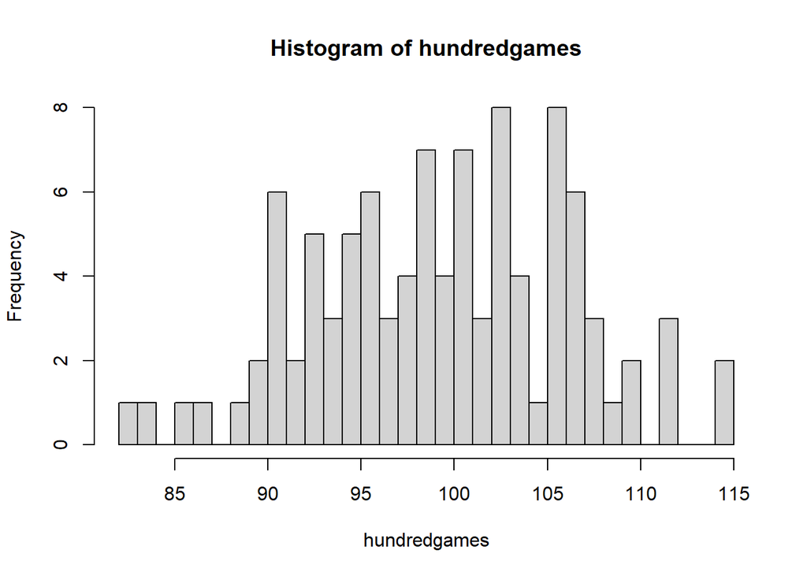

```r
hist(hundredgames, breaks = length(table(hundredgames)))
```

We can see there are more games around the hundred heads out of two hundred mark, and it tails off. But it’s messy.

What happens if we increase the total number of games by **a lot**? Say, to a hundred **thousand**? (Still with 200 coin flips per game?)

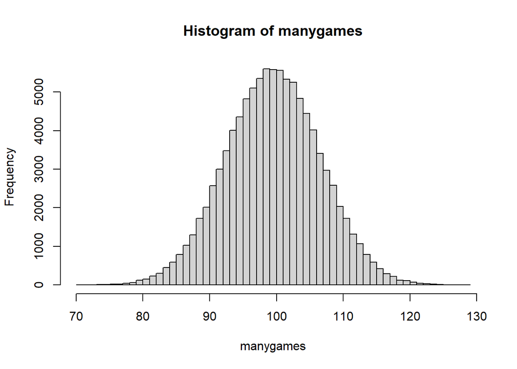

```r
manygames <- rbinom(n = 100000, size = 200, prob = 0.5)
hist(manygames, breaks = length(table(manygames)))
```

A hundred thousand games, each with 200 coin flips, produces **a much cleaner pattern**. What see here is **the binomial distribution**: in this case, we can see **the probability, for 200 coin flips, for how many would be heads** (and the same for any other 0.5 probability Bernoulli trial like coin flipping.)

Now we have so many repeats of the same game of 200 coin flips, **we can ask questions about probability**. For example:

> **What’s the probability of getting more than 115 heads if one game is flipping a coin 200 times?**

With this many repeats of the game, **probability is the same as the proportion of values**. So we just need to **find the proportion of values above 115**. which we can do with a logical operator:

```r
manygames > 115
```

Oops, though that just spits out “is this value > 115” for each value in the vector. But remember what we saw above: **R will treat TRUE and FALSE as 1 and 0**, so we can just find the mean:

```r
mean(manygames > 115)
```

```
## [1] 0.01336
```

A visual reminder of what we just did - we’ve just **counted the number of observations to the right of line on the distribution and found as a proportion of *all* observations**.

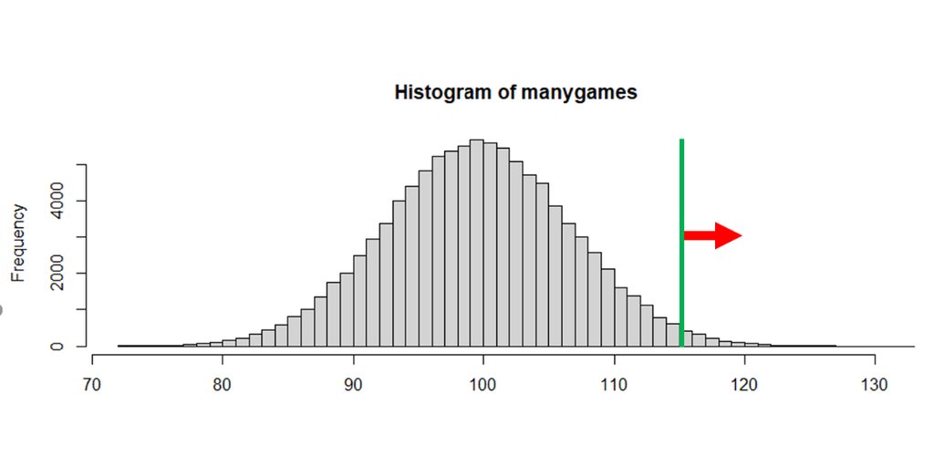

Now - when R finds these proportions itself, it doesn’t use a vector of discrete values like this. Its uses **exactly the same curve we can see here, but a mathematical version of it.** This curve has some of these features:

- It’s called a **probability density function (PDF)**. For these, **all the values under the curve add up to a probability of one**, so a PDF represents **all possibilities**. So - as we’ll see in a moment - any point on that curve can give you the **exact probability of some event occurring**.

Let’s see what that looks like for our 100 thousand games with 200 coin flips per game. We can add an argument to `histogram` to make it show us the data as a probability density. The `freq = FALSE` argument tells `histogram` not to just count the observations, but to show them as a proportion/probability/density.

**Note the vertical axis here**: nothing much above 0.05. Any single point on the x axis only has a low probability of occurring, though ones near the peak have a higher probability.

```r
hist(manygames, breaks = length(table(manygames)), freq = FALSE)
```

We can lay a density curve over the top of that by using the lines function. `density` by default will give the probability density, hence the name:

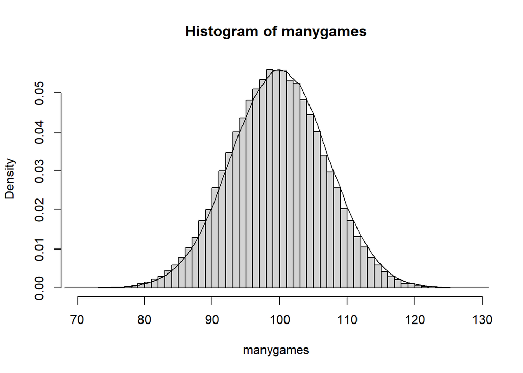

```r
lines(density(manygames))
```

OK, so let’s pause for a second and recap where we got to:

- We’ve played a game of 200 coin flips, and rerun it a hundred thousand times
- From that, we’ve seen that we get a **distribution** of how many heads came up per game, spread either side of a hundred
- We’ve plotted that to see what the **probability density** looks like
- We’ve seen that we can **find the probability that the number of heads was above some value we chose** (we could have done the same for below).

Now - rather than actually generating all those many repeats of the game, a couple of other members of the family of distribution funtions **lets us find the probability of events occurring** much more quickly. These use the mathematical version of that curve, and so the number will be slightly different to that generated by our method above. But **the principles are exactly the same**.

To start, if we wanted to ask again: for a game of 200 coin flips, what’s the probability of getting more than 115 heads? We can use the `pbinom` function. Compare this to your previous use of `mean`.

We put the following into `pbinom`:

- `q`: the number of heads / “successes” we want to know the probability of - the default for `pbinom` is “the probability below this value”. We can change that with the `lower.tail` argument so it’s “probability above this value”. `q` here is short for `quantile` from which we count values.
- `size` is just the number of flips per game, in our case, same as above.

And we don’t need the number of repeats, as R will just use the mathematical curve of the PDF. So:

```r
mean(manygames > 115)
```

```
## [1] 0.01336
```

```r
pbinom(q = 115, size = 200, prob = 0.5, lower.tail = FALSE)
```

```
## [1] 0.0140627
```

> **Exercise: see what difference increasing the repeat of games from 100,000 to a million makes to how close our actually-counting vs R’s mathematical version get**

So: R’s mathematical version is doing the same thing as our proportion-finding, except it’s finding the area under the curve (integrating) using a perfect description of that curve. **But it’s still the same principle as above.**

Another member of the `binom` function family can **pick out the probability of an exact event**. Doing the same thing with our manually-created distribution, we can ask:

- What was the probability of getting 100 heads out of 200 flips?

For a single coin, it’s 50/50, and we can see that the 50/50 probability is at the centre of the distribution - but it’s clearly not a 50% chance when there are that many coin flips. So, what is it? We can just check directly, again with a **logical operator**. We’ll ask *“what proportion of 200-flip games ended up with a hundred heads?”*

```r
mean(manygames == 100)
```

```
## [1] 0.05585
```

A little over 1 in 20. If you look back at the density plot above, **you’ll see that matches what’s on the y-axis for that central 100-heads point.**

The equivalent when working with the PDF directly is the following. As with our == test, this is reading off **an exact point on the density curve**. We tell it:

- `x`: the number of heads we want to know the probability of
- `size`: the number of coin flips per game
- `prob`: probability per coin flip, 0.5 for a fair coin as always

```r
dbinom(x = 100, size = 200, prob = 0.5)
```

```
## [1] 0.05634848
```

If you’ve used your million-times object, those two values will be very close.

# Paul the psychic octopus

Let’s use what we just learned to check how likely Paul’s guesses were. We’ll check ‘manually’ using the many-repeats method, then use the more mathematical version.

What we want to know: *is Paul doing any better than we’d expect from just randomly guessing each match?*

This has the structure of a **null hypothesis test**: we’re asking “if our datapoint came from a completely random process, how often could we expect that value, or something more extreme?”

This is exactly the same structure as coin flips: we could use a coin flip to pick the matches, in fact. We have **fourteen games**, each with a binary outcome, so that’s equivalent to 14 coin flips.

First, let’s just do `n=1` “games” - just the one game - and `size = 14` coin flips in that one game. Rerunning several times, it jumps around the expected value of 7 “successes” for 14 trials.

```r
#Here's one coin flip / one Bernoulli trial fourteen times
#The number we get is the number of "successes" or heads, in the coin examples
rbinom(n = 1, size = 14, 0.5)
```

```
## [1] 9
```

As before, to get a distribution of what that looks like if repeated, we can just increase the number of `games` / `n` / ‘observations’. Let’s also **assign to an object** to keep all those. I’ve used a hundred thousand repeats:

```r
matchguesses <- rbinom(n = 100000, size = 14, 0.5)
```

Then, as before, check how many were guessed correctly on each try of 14 guesses (“successes”) with table before sticking in a histogram. Again, we’ll have one bin in the histogram for each entry in the table:

```r
table(matchguesses)
```

```
## matchguesses
##     0     1     2     3     4     5     6     7     8     9    10    11    12
##     8    83   523  2187  6166 12260 18427 20910 18187 12228  6132  2234   557
##    13    14
##    95     3
```

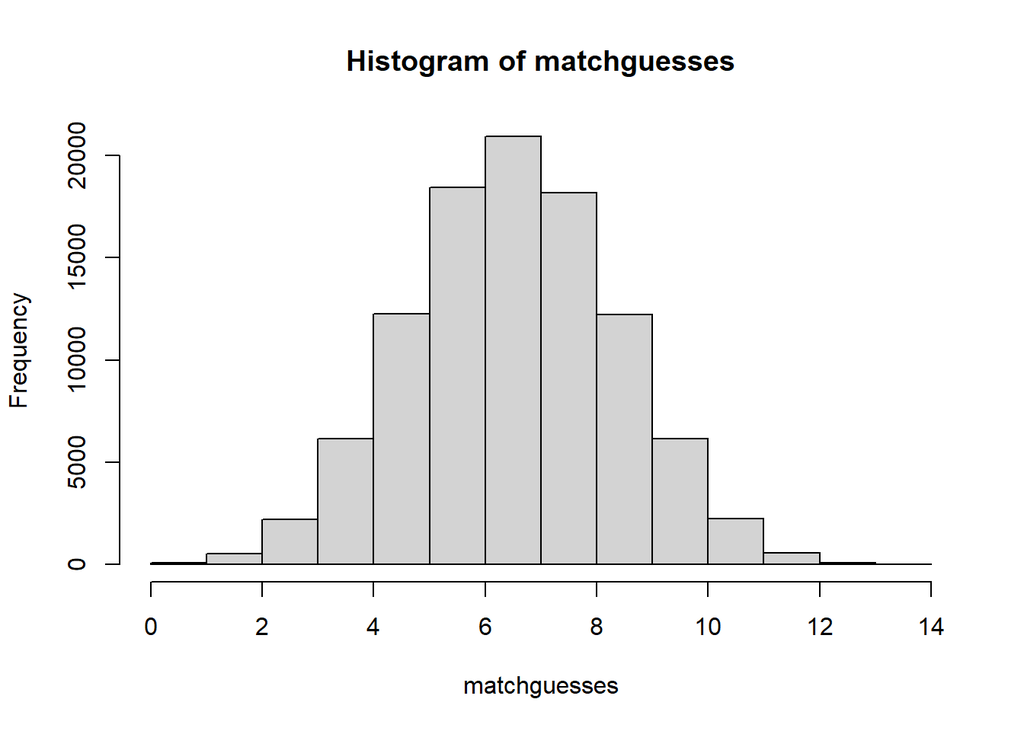

```r
hist(matchguesses, breaks = length(table(matchguesses)))
```

So, Paul’s 12 guesses - how often could we expect a value like that, or more extreme? Using our logical operator / mean approach, we can check. We want all values more than 11 (so it includes 12):

```r
mean(matchguesses > 11)
```

```
## [1] 0.00655
```

And again, we could use R’s more mathematical method that uses the full density curve. We tell it `lower.tail = FALSE` so it gives us values **above** the cutoff we set. Because it’s the exact density curve, the value won’t quite match, but it should be close.

```r
pbinom(q = 11, size = 14, prob = 0.5, lower.tail = FALSE)
```

```
## [1] 0.006469727
```

> **Exercise: repeat that for Mani the parakeet, who lives in Singapore. Mani had a go at the 2010 World Cup as well - he managed all of the quarter-finals but didn’t do so well after that. His total success rate was *5 out of the 7* he guessed at. Work out the probability of getting that many guesses if you were calling world cup games with just a coin flip. use the manual approach and the `pbinom` function. Reminder: you set the value *above which* you want the probability.**

[figure not shown]

# Election ballots

Keeping with **binomial data** but moving on to inference now - **let’s use simulation again**, before we look at some actual election data. We’ll use a little pretend dataset to examine how **sampling error** works.

First, we can **make a ballot box** with 50,000 ballots in. 55% will be for candidate 1, 45% for candidate 0. We use `as.integer` to make sure it rounds properly. Our ballot box will just be **a plain vector with ones and zeroes in.**

So: **we *know* candidate one has 55%** before we start. But we want to see what we can **infer** from a smaller sample.

The `rep` function just repeats whatever we give it in the first argument, for the number of times in the second. So this will fill the ballot box with 27500 1s and 22500 zeroes.

```r
allballots <-  50000
ballotsforcandidate1 <-  as.integer(allballots * 0.55)

ballotbox <- c(
  rep(1,ballotsforcandidate1),
  rep(0,allballots-ballotsforcandidate1)
)

table(ballotbox)
```

```
## ballotbox
##     0     1
## 22500 27500
```

Let’s imagine **we’ve counted a hundred ballots**. We can use the `sample` function to sample once from the ballot box. The `replace` argument is FALSE by default, but I’m including here to show what it does: we’re not replacing ballots once they’re taken out - which makes sense, of course. This is **sampling without replacement.**

We can `table` the results - and use `prop.table` to convert to a proportion. Or, of course, use the `mean` function as we’ve been doing before to get the proportion of 1s.

> **Re-run this code repeatedly by highlighting it first, then running over. Observe again how each sample changes. Candidate one sometimes appears to be losing.**

```r
ballots <- sample(ballotbox,100,replace=FALSE)
```

```r
#look at them all
ballots
```

```
##   [1] 1 1 0 1 0 0 1 1 1 1 0 1 0 0 1 0 0 0 0 0 1 1 0 1 1 0 1 1 1 1 0 1 0 1 1 1 0
##  [38] 0 1 1 0 0 0 0 1 1 0 0 1 0 0 0 1 1 0 1 1 0 1 1 0 0 1 1 0 1 0 0 0 1 0 1 0 1
##  [75] 0 1 1 1 1 0 1 1 1 1 1 1 1 1 0 1 1 1 1 1 1 1 0 0 1 0
```

```r
#What did we get from one sample?
table(ballots)
```

```
## ballots
##  0  1
## 42 58
```

```r
#And getting the proportion using prop.table
prop.table(table(ballots))
```

```
## ballots
##    0    1
## 0.42 0.58
```

```r
#Or as we've done before, just use mean
mean(ballots)
```

```
## [1] 0.58
```

We can keep the proportion for candidate 1 by accessing the right index in table. Let’s keep that for later:

```r
#Note: we can access elements from tables by using their names:
#table(ballots)['1']

firstballot_proportion <- mean(ballots)
```

> **Keep this first ballot proportion in mind, you’ll use it later to check how extreme (or not) it is**. Everyone’s will be slightly different.

So - we can see there is **sampling error** in our hundred ballot sample. Let’s **take many samples to look at the shape of that sampling error**.

Let’s **define a function to do this for us**, so we can easily repeat many times. **Feel free to copy this from the online version of the workbook.**

The function is taking two arguments: an `input_ballotbox` we want to find the proportion for, and the number of ballots per sample to take.

We’ll use `mean` again to get the proportion for candidate 1.

this is **just doing the same thing we just did** but putting those two lines into a function will let us pull that single number out easily.

```r
ballotsample_proportion <- function(input_ballotbox, numberofballots_to_sample){

  ballots <- sample(input_ballotbox,numberofballots_to_sample,replace=FALSE)
  return(mean(ballots))

}
```

Now, we can use the `replicate` function to do our timeloop thing and repeat the same one hundred ballot sample, getting the **proportion of votes candidate 1 receives for each 100 ballot sample**. Just tell it how many times to rerun (ten thousand in this case) and the function you want to replicate. We’ll keep the results in an object called `resampled_proportions`. It might take a few moments to run.

```r
resampled_proportions <- replicate(10000,ballotsample_proportion(ballotbox,100))
```

Once run, let’s look at the distribution - how different all those ten thousand repeats of a hundred ballots were in the proportion they find for candidate 1. You can also place your first ballot proportion on this with a line, using `abline` and setting `v`, which adds a vertical line.

```r
hist(resampled_proportions, breaks = 50)

abline(v = firstballot_proportion, col='red',lwd=3)
```

The mean of all our resamples **centres on the actual population value**, unsurprisingly:

```r
mean(resampled_proportions)
```

```
## [1] 0.549154
```

We can add that to our plot using `abline` again. The arguments in `abline` set the line width (`lwd`) and the line type (`lty`), in this case to a dashed line. Just google “R line types” to find a guide for this number. They’re also listed in the ggplot cheatsheet you can access via the help menu - it lists them as:

- 0 = “blank”, 1 = “solid”, 2 = “dashed”, 3 = “dotted”, 4 = “dotdash”, 5 = “longdash”, 6 = “twodash”

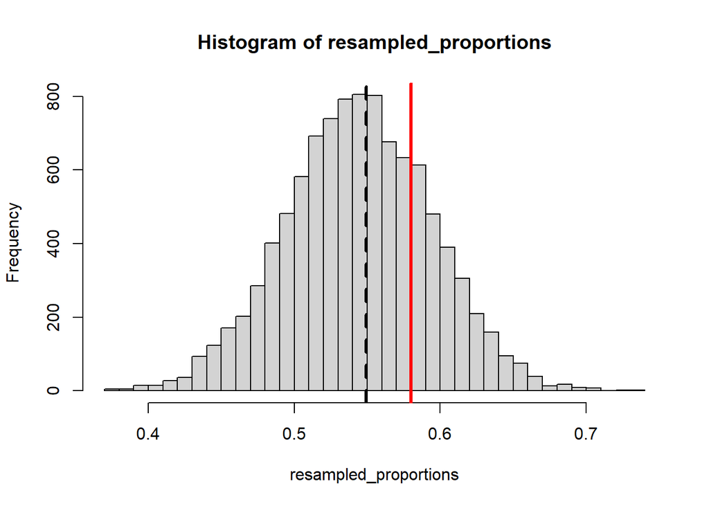

```r
abline(v = mean(resampled_proportions), col='black',lwd=3, lty =2)
```

We can see here what spread of proportions we’d get from the full ballot data, if we repeated. We’ve been able to use simulation to see what the **sampling error** looks like. Recall, samplings taken repeatedly will produce a normal distribution (this is the central limit theorem), so we know it’s symmetric either side of the mean.

From this, we can make some **confidence intervals** that will tell us - for 100 ballots - how sure we could be (if we didn’t know it) that the *real* proportion lies within those intervals’ bounds. (We’re doing this to illustrate how it works, rather than as a way to actually acquire confidence intervals.)

We can use **standard deviations** as our measuring stick to set how wide the confidence intervals are. Recall, the mean plus and minus this number of standard deviations covers these percentages of the data:

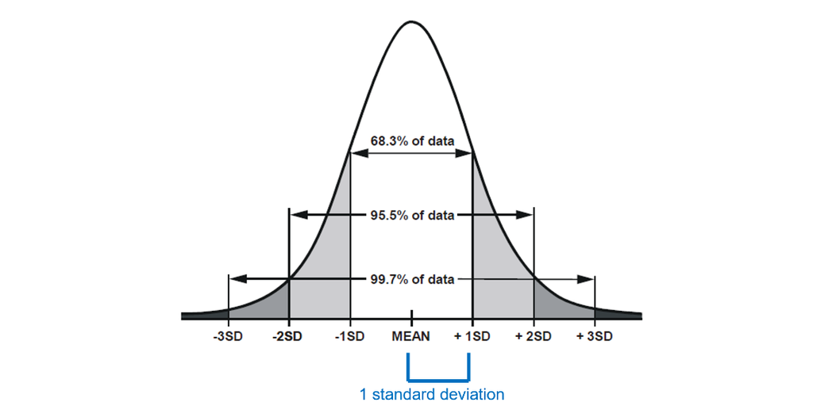

And recall: because the sampling error mean and the proportion estimate from our actual 100 ballot sample are equidistant, we can **apply the confidence intervals to our initial estimate**.

Those are slightly awkward numbers for 1,2 or 3 standard deviations (68.3%, 95.5%, 99.7%) - if we want tidier confidence intervals, we can use the following:

- 95% confidence interval: our sampled estimate, plus/minus 1.96 standard deviations
- 99% confidence interval: our sampled estimate, plus/minus 2.576 standard deviations

So let’s calculate **for a 99% confidence interval** for our original 100 ballot sample, in stages so it’s clear.

```r
x <- sd(resampled_proportions) * 2.576

confidenceinterval_lowerbound <- firstballot_proportion - x
confidenceinterval_upperbound <- firstballot_proportion + x
```

Take a look at them either in the environment pane, or output to the console:

```r
confidenceinterval_lowerbound
```

```
## [1] 0.4513166
```

```r
confidenceinterval_upperbound
```

```
## [1] 0.7086834
```

Looking at those, it’s very likely that they include the 0.5% point. If so, that means you **can’t exclude candidate 1 either winning or losing, with 99% certainty.**

> **We can use a very similar approach to test how using a null hypothesis works. How we’ll use a null hypothesis here:** if we want to try and be 99% certain that candidate 1 has won, we can ask: **If the ballot box’s total count were a perfect 50/50 split between the candidates, how improbable would our 100 ballot proportion be? Would it be less than 1% probable? If so, we can reject the null hypothesis that it’s a 50/50 split and no candidate is winning.** That’ll allow us to declare it for one of the candidates.

Note here as well, because we’re trying to find out if candidate 1 won or lost, we’ll use a **one-tailed p-value test**:

- Your first hundred ballot sample may be **above or below the 0.5 cutoff between candidate 1 winning or losing.** Depending on which it is, you’ll want to test for a different-tailed p-value. That’s because for each, we’d be asking a different question:
- If candidate 1’s proportion from 100 ballots is **more than** 0.5, we’re asking: what’s the probability, given our null of a 50/50 proportion, of seeing a result from 100 ballots **equal to or *higher* than** the proportion we actually have? If that probability is less than 1%, we’ll be confident declaring it for candidate 1. There’d be less than a one percent chance of getting that result if the data were split 50/50 - we’re 99% sure candidate 1’s **true proportion** is what we got from the 100 ballots, **or higher**.
- Exactly the opposite applies if the 100-ballot proportion you got is **less than 0.5**. If candidate 1’s proportion from 100 ballots is **less than** 0.5, we’re asking: what’s the probability, given our null of a 50/50 proportion, of seeing a result from 100 ballots **equal to or *lower* than** the proportion we actually have? If that probability is less than 1%, we’ll be confident declaring it for the *other* candidate, candidate 0 (we’re 99% sure candidate 1 has lost). There’d be less than a one percent chance of getting that result if the data were split 50/50 - we’re 99% sure candidate 1’s **true proportion** is what we got from the 100 ballots, **or lower**. There’s less than a 1% chance candidate 1 has won.

The plot below illustrates both of these. Note: a *two-sided p-value* would just be **both of those upper and lower counts added together.** That’s just asking whether our sample proportion is more extreme **in either direction**, if we don’t care about polarity. We do care in this case, though. (More on that in a moment.)

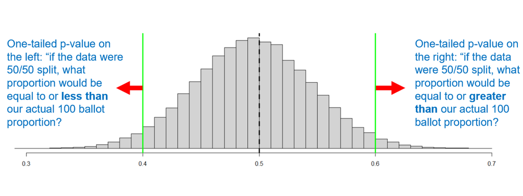

First, let’s **generate our null distribution: the spread of proportions we’d expect if we repeatedly counted a hundred ballots from a ballot box with a 50/50 split**. We’ll do the same as we did above, just tweaking to make 50/50. We previously set `allballots` to 50 thousand, so we can re-use that. We’ll use `table` to check the proportions are as we want them.

```r
ballotsforcandidate1_null <-  as.integer(allballots * 0.5)

ballotbox_null <- c(
  rep(1,ballotsforcandidate1_null),
  rep(0,allballots - ballotsforcandidate1_null)
)

table(ballotbox_null)
```

```
## ballotbox_null
##     0     1
## 25000 25000
```

Then we can **re-use our `ballotsample_proportion` function** to get a load of re-samples of a hundred ballots, to see what the distribution would be under the null. We’ll repeat a hundred thousand times to get plenty - might take a little while to run.

```r
resampled_proportions_null <- replicate(100000,ballotsample_proportion(ballotbox_null,100))
```

Let’s look at the resulting proportions using `hist`, and adding in (a) the 50/50 point at 0.5 and (b) our original 100 ballot proportion that we want to test, so we can see where it falls on the probability density if we had a 50/50 split. This will be **the same spread as re-sampling from the actual ballot box, as did above, just now centred on 0.5 or 50/50 split**.

Note again: everyone’s original ballot proportion will be slightly different as it was randomly sampled.

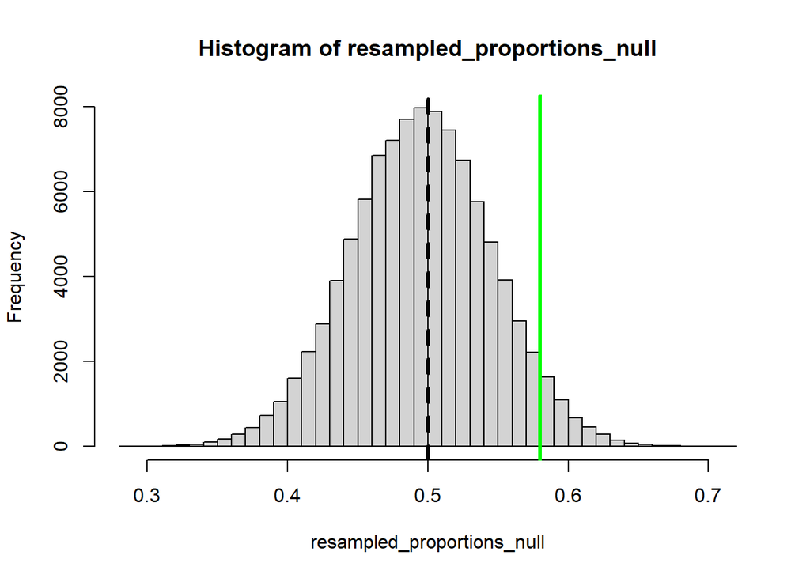

```r
hist(resampled_proportions_null, breaks = 50)

#0.5, the 50/50 vote split line.
abline(v = 0.5, col='black',lwd=3, lty =2)

#Add in a line that marks our original 100 ballot proportion
abline(v = firstballot_proportion, col='green',lwd=3)
```

So - **note whether or not your original ballot proportion is above or below the 50/50 split line**. We’ll do a different one-tailed test in each case, as described above.

- If your original 100 ballot proportion is **more than 0.5**, you want to check **what proportion of the null is equal to or *more* than that proportion**. We’re asking: if the data were a 50/50 split, how likely would it be to get our actual datapoint **or something more than that?**
- If your original 100 ballot proportion is **less than 0.5**, you want to check **what proportion of the null is equal to or *less* than that proportion**. We’re asking: if the data were a 50/50 split, how likely would it be to get our actual datapoint **or something less than that?**

We use the same code as we did for Paul the Octopus - just finding the mean of a logical operator test. Here’s both - use which matches your data.

```r
#If doing a right-hand one-tailed test ("greater than")
mean(resampled_proportions_null >= firstballot_proportion)

#If doing a left-hand one-tailed test ("less than")
mean(resampled_proportions_null <= firstballot_proportion)
```

```
## [1] 0.06635
```

Most likely, you’ll find a value that’s not less than p=0.01, meaning we **can’t reject the null hypothesis with 99% certainty** that we could have got our actual ballot proportion from 50/50 data.

> **So, that’s the roundabout way, so we could see how p-values work with a proportion test. The same principles apply to any other kind of hypothesis test or confidence intervals - the difference will just be the types of data generating process going on, and so the distributions may be different. But we’ve seen how to work with one distribution in different ways - those ideas apply to all other distributions too, and R supplies the same family of functions for working with all of them.**

> **But now let’s see how to do all that just using R’s simple `prop.test` function instead**. The arguments going into `prop.test` will be:
- `x`: the count of “successes” - in our case the count of ballots for candidate 1
- `n`: the total “trials” - here, that’s the number of ballots in the sample, which is a hundred
- `p`: is the underlying probability we’re testing against - so here, we’ll use our null assumption of a 50/50 split, and set it to 0.5 probability. Note: this is slightly confusing, given we’re talking about p-values. In both cases, `p` stands for probability, but it’s being used differently here, to set the probability for our null. (You could of course test against other probability assumptions.)
- `conf.level`: set as a probability, so we can use 0.99 for 99% confidence intervals

**There’s also an `alternative` argument.** You can set your type of p-value test with this. To do a one-tailed test, you can set to *either* **“greater”** or **“less”** - matching the choice we made above.

Let’s do that first, then we’ll look at one more option.

Note - we can access our count of candidate 1 ballots using `table` again.

```r
#Ballots for each candidate
table(ballots)

#This gets the number for candidate 1
#We can put that straight in to prop.test
table(ballots)['1']

#If your proportion was > 0.5
prop.test(x = table(ballots)['1'], n = 100, p = 0.5, conf.level = 0.99, alternative = 'greater')

#If your proportion was < 0.5
prop.test(x = table(ballots)['1'], n = 100, p = 0.5, conf.level = 0.99, alternative = 'less')
```

```
##
##  1-sample proportions test with continuity correction
##
## data:  table(ballots)["1"] out of 100, null probability 0.5
## X-squared = 2.25, df = 1, p-value = 0.06681
## alternative hypothesis: true p is greater than 0.5
## 99 percent confidence interval:
##  0.4590729 1.0000000
## sample estimates:
##    p
## 0.58
```

> **You should see a p-value that’s close to the one you found manually. It won’t be exact as the manual method is still a sample of the sample error, if a large one, and `prop.test` uses the mathematical probablity density function curve to find the area under the curve, so it’s more precise. (It uses a `correct` argument, set to TRUE by default, to correct for discrete errors.)**

Slight issue here though: **for one-tailed tests, the confidence intervals will be open at one bound - either set to 0 or 1 depending on which side of 0.5 your 100 ballot proportion fell**.

We can get the actual confidence intervals by just leaving the `alternative` argument out. The default, if we don’t set it, is `two.sided` - recall from above, this is finding the probability of **both** the lower and upper extremes, summed together.

```r
prop.test(x = table(ballots)['1'], n = 100, p = 0.5, conf.level = 0.99)
```

```
##
##  1-sample proportions test with continuity correction
##
## data:  table(ballots)["1"] out of 100, null probability 0.5
## X-squared = 2.25, df = 1, p-value = 0.1336
## alternative hypothesis: true p is not equal to 0.5
## 99 percent confidence interval:
##  0.4469359 0.7027299
## sample estimates:
##    p
## 0.58
```

This will give the actual upper and lower confidence interval. You can also use the p=value here - and we can **take advantage of the fact that the underlying null distribution is symmetric**:

- To get a one-tailed p-value from a two-tailed, you just need to divide by 2.
- Likewise, times by two to get two-tailed from one.

> **So, most likely, we’ve found that from our initial 100 ballots, we haven’t been able to reject the null hypothesis at p < 0.01. And the confidence intervals are crossing the 0.5 line, telling us the same thing the null test does, in a different way: we can’t be 99% sure the real ballot count isn’t above *or* below 0.5, so we can’t declare a winner with 99% certainty.**

> **EXERCISE: The data below is a ballot count of 5000 ballots from the 2019 UK Election, for Sheffield Hallam ward.**
- The two main candidates were:
- Olivia Blake (Labour) - **coded as 1 in this data**
- Laura Gordon (Liberal Democrat) - **coded as 0 in this data**

(Note: other candidates have been removed to make this a simple proportion test.)

With your 5000 ballot sample, **work out using `prop.test` whether you’re 99% confident one of the two candidates has won.**

Let’s load the data first. It’s in **RDS format** - this is R’s own object compression method, and can be used to save **any** R object. Here, we’re loading from the internet as usual.

```r
hallam <- readRDS(url('https://bit.ly/smi106hallam'))
```

Take a look at the data and work out the proportion in these 5000 ballots for Olivia Blake:

```r
table(hallam)
```

```
## hallam
##    0    1
## 2406 2594
```

```r
mean(hallam)
```

```
## [1] 0.5188
```

Using those numbers, and the information above, check whether you can tell if one of the candidates won. Either:

- Use a one-tailed test, having decided whether the value being assessed (1) is above or below 50%
- Use a two-tailed test and then divide by 2 to get the one-tailed p-value
- And/or use a two-tailed test, and a confidence level of 99%, so you can see whether the confidence intervals cross 0.5 (thus including the possibility that the candidate either won or lost, and you can’t 99% rule that out).

> **ANOTHER EXERCISE, IF THERE’S TIME: Going back to working with probability density functions.**

First, let’s look at the full **probability density function** for what Leclerc did. Here, we’re showing **how likely it is that Leclerc would have got a particular count of heads** by using the `dbinom` function. We can then plot it (using some code from the link in the comments).

Things happening here worth noting:

- We make a vector from 0 to 4040: that’s **every single possible outcome from flipping a coin 4040 times** (however super-unlikely most of those are).
- We check the probability of each of them by using the `dbinom` function to read off that probability.
- I’ve reduced the `xlim` value to zoom in on the area where there are actual probabilities - the tails are next to impossible, as we saw with Rosencrantz and Guildenstern are dead.
- We also add lines for the “expected” value of an even split - 2020 heads, and the actual number of heads Leclerc got

Note here that `dbinom` can take in a **vector of values** and give us the probability for each.

```r
#Georges-Louis Leclerc, C18th: flipped a coin 4040 times and got 2048 heads
dbinom(x = 2048, size = 4040, prob = 0.5)
```

```
## [1] 0.00851532
```

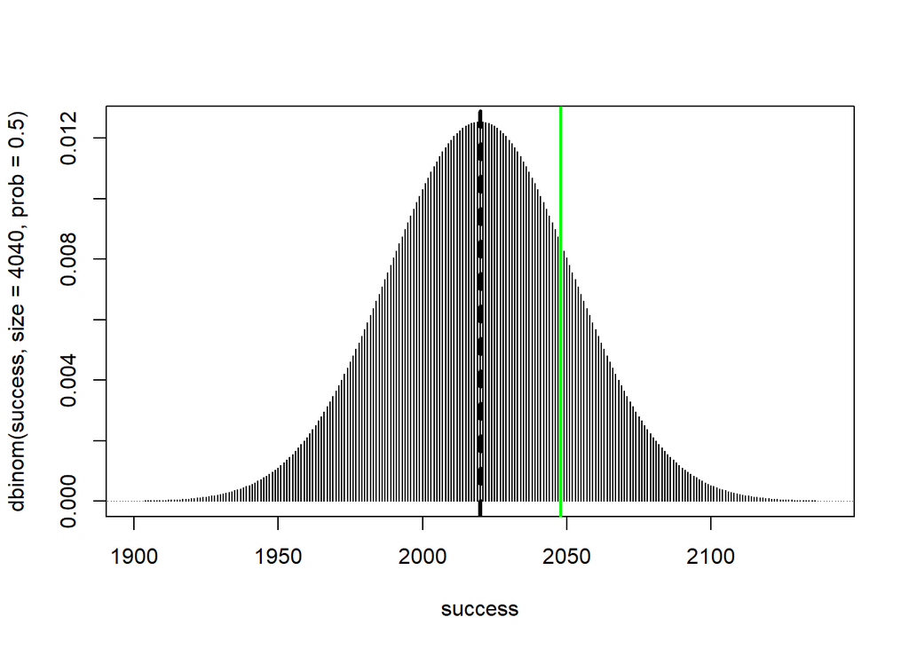

```r
#Used code from https://www.statology.org/plot-binomial-distribution-r/

#All possible outcomes from zero heads to 4040 heads
success <- 0:4040
plot(success, dbinom(success, size=4040, prob=.5),type='h', xlim = c(1900,2140))
abline(v = 2020, col='black', lwd=3, lty=2)
abline(v = 2048, col='green', lwd=2)
```

Now - we can read off the **exact probability of getting 2048 heads**, as Leclerc did, using `dbinom` to read off a point on the probability density function (the d stands for density).

```r
dbinom(x = 2048, size = 4040, prob = 0.5)
```

```
## [1] 0.00851532
```

So the chances of him getting **that exact number of heads** is actually **really low**. But that doesn’t seem right - we want some way to quantify the fact that the value he got isn’t far from the expected 50/50 split. So, what do we do?

Well, the question we may want to answer is this:

- What was the probability of Leclerc getting the number of heads that he got, or any other heads within the same range of the expected value? That is, what’s the probability of the marked area in the image below?

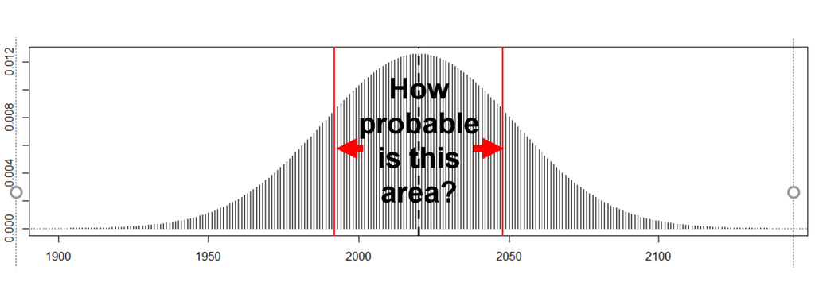

> The exercise is to **do some sums on the distribution using `pbinom`, that can give us probability sums across ranges of the PDF.**

Some tips on how to find that sum. First - recall that pbinom will sum the probability under the curve for us. So e.g. if we ask it, what was the probability of getting a head count **higher** than what Leclerc got? Reminder: setting `lower.tail = FALSE` means we get the probability for the higher tail - all values above 2048 heads.

```r
pbinom(q = 2048, size = 4040, prob = 0.5, lower.tail = F)
```

```
## [1] 0.1849201
```

OK, so that tells us the probability **to the right of Leclerc’s actual head count**.

What do we do to get the area in the image above? Some very basic maths. Recall just two things:

1. The distribution is symmetric, so 2 times the number above gives the probability of values more extreme than what Leclerc got, including if he got a similar number of heads but **less than** the expected value (i.e the probability sum **outside** of the range marked in the image above).
2. Probabilities sum to 1, so finding the central area is just a simple subtraction.

> **How probable was it that Leclerc got something in that range marked in the image above? Have we quantified how unsurprising his actual result was?**

**If you get that done, you could repeat for Pearson’s result too.**